# Analyzing Trends within Joseph Smith’s Polygamy

Spencer Patten

## Background

As a member of the Church of Jesus Christ of Latter-day Saints (a.k.a. LDS Church or the Church), I often hear criticism of my faith’s theology and history. I typically suspend my acceptance of such claims until I perform my own research. One of the more common attacks is regarding the character of the Church’s founder, Joseph Smith. Smith claimed that God commanded him to institute the practice of plural marriage, meaning the marrying of more than one wife. He often comes under fire for this, based on the assumption that a man wouldn’t have 35 wives unless he was after sex.

Thanks to the work of LDS and Non-LDS historians, we have a pretty good idea with what happened in most of these plural marriages. Using this historical data, we can assess different questions about Joseph Smith’s Polygamy. By doing so, I hope first and foremost to uncover the truth. I have the firm hope that the truth will show that Smith was a reputable man, free from hypocrisy and acting within his cultural context. Should the evidence be sufficient to indicate sexual immorality as defined by the LDS Church, the trustworthiness of the institution may be called into question.

## Structure and Methodology

### Primary Question

The analysis will seek to answer the primary question:

**“Did Joseph Smith engage in questionable or inappropriate actions through the practice of polygamy?”**

Six secondary questions will be analyzed through various visual and summary measures. If appropriate an inferential statistical test will be performed. When answering each question, Smith will be assumed innocent (within the law, adhering to societal norms, etc.) until there is sufficient evidence to suggest otherwise.

To control the family-wise error rate, the Bonferroni adjustment adjustment will be made to the significance level.

### Outline

In pursuit of an answer to this question, the following secondary questions will be asked :

- Are any of Joseph Smith’s sexual relations consistent with pedophilia?
- Did Smith hide sexual realtionships from his first wife, Emma?
- What is the relationship between the type of sealing and evidence of sexuality?
- Despite the illegality of polygamy, was Smith otherwise within local marriage laws?
- How do the ages of his brides compare to contemporary marriage trends?
- How do the age difference between him and his wives compare to contemporary trends?

### Data Sources

Historical data such as the names, ages, and other factors was sourced from the work of Brian Hales. Observational data including the strength of any evidence of sexual relations were not the author’s, but sourced from the work of Brian Hales. The author reviewed the primary and secondary historical evidences to determine whether Emma Smith was aware of the plural marriages. All data regarding Joseph Smith’s Polygamy was sourced from the various pages on Brian Hales’ website, josephsmithspolygamy.org.

Data used from the 1850 US census was retrieved from the IPUMS database[^1]. The data set used was a random sample of census records totaling 1% of the US population surveyed. When retrieving the data, the parameter was set to include the households wherein at least one individual had been married within the last year. This census data was the closest to the occurrences of Smith’s marriages, most of which happened in the early 1840’s.

When determining whether or not Emma Smith was aware of the sealings. The historical record indicates that she gave prior approval to several of them. Other sources indicate that the plural wife, after the sealing, proceeded to live with the Smiths and that Joseph spent nights with them. Other times, it was indicated that Joseph would travel to visit them shortly after their sealing, with the intention of the trip being to celebrate the union. As such cases overlapped with Hales’ put forth evidence of sexuality, It was taken or inferred that Emma Smith was aware of the unions either prior to or shortly after they occurred. Where the record does not contain sufficient evidence to persuade the author that Emma did know, it is inferred that she did not.

The following table displays the data for Joseph Smith’s Polygamy.

|  | Name | Age | JS Age | Age Diff | Type | Ev of Sexuality | Emma Aware? |
| --- | --- | --- | --- | --- | --- | --- | --- |
| 1 | Helen Mar Kimball | 14 | 37 | 23 | Eternity | None | No |
| 2 | Flora Ann Woodworth | 16 | 37 | 21 | Eternity | None | No |
| 3 | Sarah Lawrence | 17 | 37 | 20 | Time and Eternity | Moderate | Yes |
| 4 | Lucy Walker | 17 | 37 | 20 | Time and Eternity | Strong | Yes |
| 5 | Sarah Ann Whitney | 17 | 36 | 19 | Time and Eternity | None | No |
| 6 | Maria Lawrence | 19 | 37 | 18 | Time and Eternity | Moderate | Yes |
| 7 | Emily Dow Partridge | 19 | 37 | 18 | Time and Eternity | Strong | Yes |
| 8 | Malissa Lott | 19 | 37 | 18 | Time and Eternity | Strong | Yes |
| 9 | Zina Diantha Huntington | 20 | 37 | 17 | Eternity | None | No |
| 10 | Eliza Maria Partridge | 22 | 37 | 15 | Time and Eternity | Moderate | Yes |

[output cut: 25 more lines]

### Data Wrangling

In order to most accurately compare the data from the 1850 US Census records and Smith’s plural marriages, the following steps were taken to wrangle the data:

1. The Census data was filtered to only show each household that had at least one person married within the last year, and the columns for household ID, female age, and male age were selected
2. The data was pivoted to cause each row to contain the age data from each household. Some households had 1, 3, or 4 individuals married withing the last year in them. Unsure of what this indicated, the data was filtered to ensure that only households with one recently married female and one recently married male were included. It is assumed that such households would only include recently married couples, and that the ages recorded by the census are the ages those individuals were when married.
3. To make the inferential statistical tests more accurate, the data was also filtered at this stage to only include males ages 22 to 37. It was within this range that Smith was sealed to each of his plural wives. It is hoped that, by analyzing the data for contemporary males married with the same 15 year span, the results of the tests will be more accurate.
4. A new column was made in the census data that subtracted the woman’s age from the man’s age. The same was done in the polygamy dataset. Thus, a positive number indicate an older husband and a negative number an older wife. A column that indicated which group was represented was also added.
5. After ensuring the columns were selected and ordered the same, the two data sets were combined to form one, with each row displaying female age at marriage, male age at marriage, age difference ($\text{male age} - \text{female age}$), and the group of origin.

#### Reveal Wrangling Code

```r
# --- Initial Wrangling for US Census Data ---


#Whittling data down to the essentials.

mawaged <- census_data %>%
  mutate(gender = case_when(SEX == 1 ~ "Male", SEX == 2 ~ "Female")) %>%
  filter(MARRINYR == 2) %>%
  select(SERIAL, AGE, gender)


# Makes each row a household rather than an individual
# Household based on SERIAL column, which is a unique number assigned to each household

by_household_raw <- mawaged %>% pivot_wider(names_from = gender,
                                            values_from = AGE,
                                            names_prefix = "age_")


# Ensures that the ages are one value (not NA) that is a number
# Makes sure each household has one man and one woman.
# Only includes males ages 22-37, the min and max age Smith was married

by_household <- by_household_raw %>%
  filter(age_Male %in% 22:37, age_Female %in% 1:1000)


# Ensures age values are numeric
# Creates and populates age_diff column and group columns (the latter for future distinction)
# selects necessary columns, orders them, and renames them

by_household <- by_household %>%
  mutate(age_Male = as.numeric(age_Male),
         age_Female = as.numeric(age_Female)) %>%
  mutate(age_diff = age_Male - age_Female,
         group = "1850 Couples") %>%
  select(f_age = age_Female, m_age = age_Male, age_diff, group)


# --- Initial wrangling for Joseph Smith's Polygamy Data ---

# Creates group column
# selects necessary columns, orders them, and renames them

selective_polygamy <- polygamy %>%
  mutate(group = "JS Polygamy") %>%
  select(f_age = age, m_age = js_age, age_diff, group)


# --- Combining the data sets for ease of analysis and visualization ---

# binds the rows of the two wrangled dataset to put them into one unified data frame to make visualization and testing possible

occams_data <- rbind(by_household, selective_polygamy)
```

### Defining Pedophilia

Because one of the questions being asked regards Smith showing pedophilic tendencies, the term will be defined. Dictionaries contemporary to Smith do not have the term, therefore a modern definition will be used. This analysis will not seek to officially diagnose anyone with any mental disorders. Any conclusions regarding such will be, at most, observations regarding trends in the historical record. For purposes of the analysis, a synthesis of the definitions provided by the American Psychological Association and the American Psychiatric Association for pedophilia will be used as the strictest definition.

According to the American Psychological Association, pedophilia is “a paraphilia in which sexual acts or fantasies involving prepubertal children are the persistently preferred or exclusive method of achieving sexual excitement.[^2]” The Diagnostic and Statistical Manual of Mental Health Disorders, published by the American Psychiatric Association, adds that the sexual acts or fantasies are “with a prepubescent child or children (generally age 13 years or younger).[^3]”

Taking a looser definition based on these criteria, the established definition of pedophilia for this analysis will be, “any stand-alone or repeated sexual relations with an individual or individuals below the age of sixteen.” The intention behind expanding this definition is to fit the definition within the moral intuitions and sensibilities of the broader public.

## Trends within Smith’s Marriages

### Are any of Joseph Smith’s relations consistent with pedophilia?

It is often and understandably inferred that two married individuals will engage in sexual relations at some point. When it is learned that Smith had several wives under 18, inferences such as this cause many to assume he was having sexual relations with all of them.

#### Visualization

The following visualizations display age data from Joseph Smiths plural wives based on the historical evidence of sexuality put forth by historian Brian Hales.

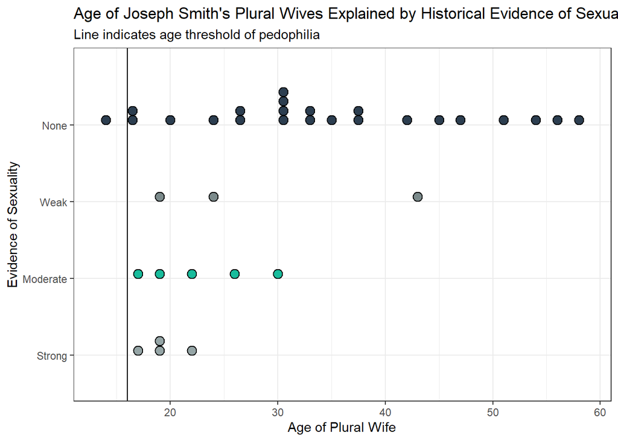

Summary Statistics of above graph

| Ev of Sex | Min Age | Avg Age | Max Age | Avg Age Diff | Number |
| --- | --- | --- | --- | --- | --- |
| None | 14 | 34.6 | 58 | 1.9 | 23 |
| Weak | 19 | 28.7 | 43 | 6 | 3 |
| Moderate | 17 | 22.8 | 30 | 13.8 | 5 |
| Strong | 17 | 19.2 | 22 | 14 | 4 |

The data suggests that there is no evidence that Smith engaged in sexual relations with anyone under the age of 17. It does appear that younger wives than average appear in the moderate and strong categories. Trends of age and age difference among his plural wives are further analyzed below.

#### Conclusion

Given the definition of pedophilia set forth, there is insufficient evidence to adopt the view that Smith had pedophilic tendencies. There is no evidence that Smith met the criteria of a pedophile.

Further study into the historical data can provide insight on a case by case basis. For more information on the issue of Smith’s sealings to young brides, [this article](https://josephsmithspolygamy.org/common-questions/14-year-old-wives-teenage-brides/) is highly recommended.

### Did Smith hide sexual realtionships from his first wife, Emma?

Especially during the early days of his practice of plural marriage, Smith’s first wife Emma Hale was not made aware of the sealings he was entering into. This has been pointed to as a betrayal of trust on Smith’s part. The complex issue deserves historical analysis, but there may be lessons to be learned from the statistics.

#### Visualizations

The following table will show Emma’s awareness of his marriages across different levels of evidence of sexuality.

Please note that the historical record is not explicit, and inferences were required to arrive at the data presented. For details regarding how the data of Emma’s Awareness was collected, please refer to the Data Sources tab under the Structure and Methodology section.

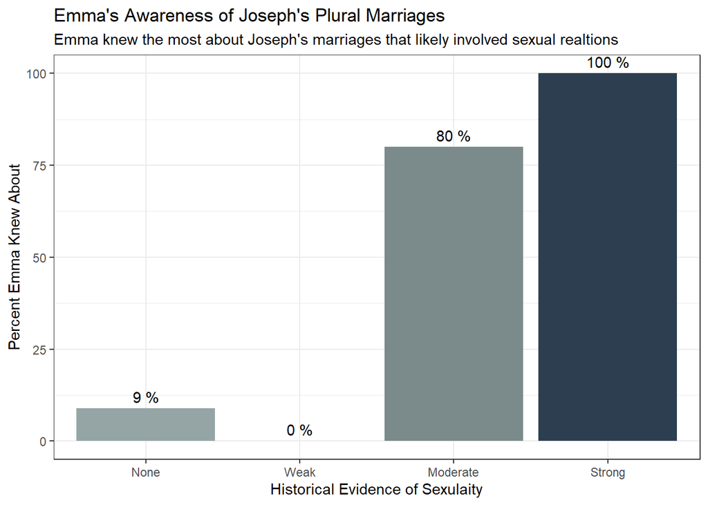

Joseph Smith was transparent about sealings with sexual relations

[output not shown]

#### Conclusion

While Smith was not fully transparent with his first wife regarding each and every plural wife, the historical data suggests that Emma was aware of the vast majority of relationships where sexuality was possibly occurring. The trends suggest that Smith was not hiding sexual relationships from his first wife.

With that said, elsewhere there is evidence that Emma had difficulty accepting the practice of polygamy. For more information on the subject of Emma’s trials with plural marriage, [this article](https://josephsmithspolygamy.org/history/emma-smith-struggles/) is highly recommended.

### What is the relationship between the type of sealing and evidence of sexuality?

Today in the LDS Church, the only sealings performed for the living are time-and-eternity sealings. That is, a man and a wife are joined in union for the rest of this life as well as in the next life. However, in the early days of the church, this was not solely the case. Sealings could be performed for time, time-and-eternity, or eternity.

#### Graph

Sealings involving time would be treated as legal marriages are, but eternity-only sealings would not. Given the LDS Church’s consistency in teaching that sexual relations be within marriage, evidence that Smith engaged in sexual relations within eternity-only sealings would imply hypocrisy.

The following graph will display the evidence of sexuality, grouped by the types of sealings.

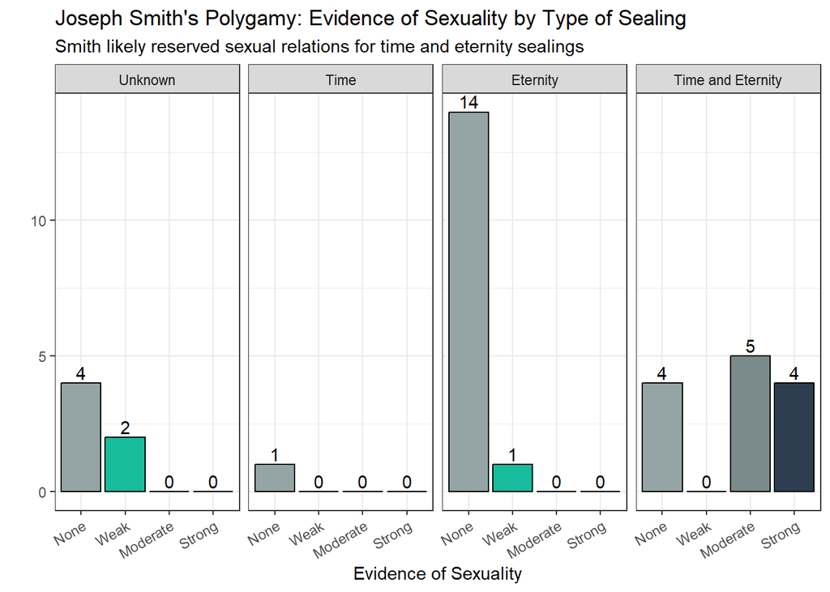

As is evident from the graph, the sealings that displayed the most evidence of sexual relations were time and eternity sealings. there are no instances of moderate or high evidence of sexuality among other types of sealings.

#### Conclusion

As type of sealing and historical evidence of sexuality are juxtaposed, it becomes clear that the only relationships with stronger evidence of sexuality (moderate to strong) were those which were treated as legal marriages. Thus, there is enough evidence to conclude that Smith was not violating the principles he taught and enforced.

It is likely that Smith viewed Time and Eternity sealings as being legitimate marriages. Thus, he did within those relationships what married people do.

## Comparison to Contemporary Trends

### Despite the illegality of polygamy, was Smith otherwise within local marriage laws?

The accusations that Smith was a pedophile primarily revolve around his being sealed to 14 year old name Helen Mar Kimball. More on that can be learned in [this article](https://josephsmithspolygamy.org/plural-wives-overview/helen-mar-kimball/). If Smith’s marriages showed to be outside of Illinois marriage laws, this would raise questions on his motives.

While the Church was in Illinois, the marriage laws stated that with parental consent, anyone female as young as 14 years old female was able to be married.[^4] Without parental consent, a female must have been 18 or older. While laws have changed much since then, in those days, it would have been legal if Smith had permission from the parents.

#### Table

While the Church was in Illinois, the marriage laws stated that with parental consent, anyone female as young as 14 years old female was able to be married[^5]. Without parental consent, a female must have been 18 or older. While laws have changed much since then, in those days, it would have been legal if Smith had permission from the parents.

The following table lists each of Smith’s plural wives under the age of 18. Stated is the sufficiency of the evidence to conclude that a legal guardian other than Smith gave approval for the plural marriage.

|  | Age | Consent of Guardian | Ev of Sex |
| --- | --- | --- | --- |
| Flora Ann Woodworth | 16 | Yes | None |
| Helen Mar Kimball | 14 | Yes | None |
| Lucy Walker | 17 | Yes | Strong |
| Sarah Ann Whitney | 17 | Yes | None |
| Sarah Lawrence | 17 | Yes | Moderate |

The table clearly shows that each bride under 18 had consent from a guardian.

#### Conclusion

While he was not necessarily bound by Illinois law (they were not legally recognized marriages), it appears that Smith fully respected the law. The adherence to the law indicates an awareness of his present social norms. Furthermore, it can be inferred that, because Smith was within the law, he was conscious of it and trying to keep it.

For more information on the issue of Smith’s sealings to young brides, [this article](https://josephsmithspolygamy.org/common-questions/14-year-old-wives-teenage-brides/) is highly recommended.

### How do the ages of his brides compare to contemporary marriage trends?

In the 1850 US Census, citizens were asked if they had gotten married within the past year. Filtering everyone who said yes and who was female will show a contemporary spread of marriage ages. If the ages of Smith’s wives are significantly less than the norm, it may be concluded that Smith disproportionately targeted young women. If this turns out to be the case, it would add to evidence of sexual deviance on Smith’s part, and reflect poorly on his character.

#### Hypootheses

Joseph’s first marriage was at age 22, and his final marriage was age 37. Thus, the best population to compare the ages of his plural wives to is women whose husbands were between 22 and 37 years of age. For a more comprehensive detailing of how the data was filtered, please refer to the data wrangling section under the Structure and Methodology section.

The assumption ($H_o$ or null hypothesis) is that there will not be significant differences in the averages ($\mu$ or mean) of the two groups.

$$H_o: \mu_\text{Avg Age of 1850 Wives} = \mu_\text{Avg Age of JS Plural
Wives}$$

The prediction ($H_a$ or alternative hypothesis) is that there will be a significant difference in the averages ($\mu$ or mean) of the two groups.

#### Visualization

To approach an answer, the distributions will first be visualized using a density plot and explained with a table.

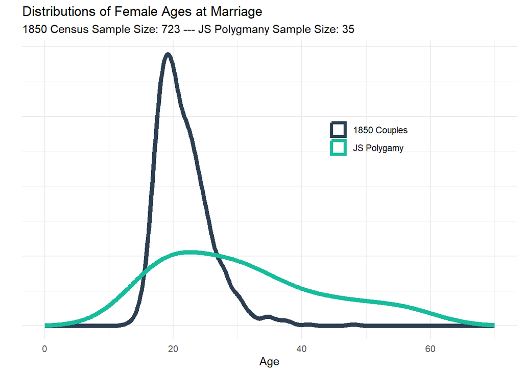

Summary Statistics: Female Ages at Marriage

| group | Min | Median | Average | Max | SD | Sample Size |
| --- | --- | --- | --- | --- | --- | --- |
| 1850 Couples | 13 | 21 | 21.68 | 48 | 4.181 | 723 |
| JS Polygamy | 14 | 30 | 30.63 | 58 | 12.41 | 35 |

While there is some skew observed, both groups are representative of the sample. The data concerning Smith’s Polygamy is all of the data of that population. The 1850 US Sample, being well over 30 and a random sample, likely represents the population well.

It appears that the group `JS Polygamy` is much more widely distributed, and contains wives with higher ages. The summary statistics indicate both groups to be fairly normal in their distributions. The means are somewhat distance from each other. A inferential test will serve to delineate any significant differences.

#### Statistical Test and Conclusion

The most appropriate test for the data in hand is an independent sample t test. This test will yield two helpful data points: a test statistic indicating the difference in averages, and a p value telling how probable it would be to randomly encounter such a difference.

A confidence level of 97.5% will be used, and thus a significance of 0.025 will be needed to accept the alternative hypothesis. A p value below the significance ($p < 0.025$) will result in rejecting the null hypothesis.

Two Sample T-test: Smith’s wives significantly older than norm (continued below)

| Test statistic | df | P value | Alternative hypothesis |
| --- | --- | --- | --- |
| -4.256 | 34.37 | 7.593e-05 * * * | less |

| mean in group 1850 Couples | mean in group JS Polygamy |
| --- | --- |
| 21.68 | 30.63 |

In other words, there is sufficient evidence to alter belief and indicate that Joseph Smith’s plural wives were older than what would be expected in that day.

### How do the age difference between him and his wives compare to contemporary trends?

The last question established that Smith was marrying disproportionately older women than men near his age and time, but it did not explain the age differences. This section will seek to give insight into the differences in age among the two groups. If it is found that Smith was sealed to women disproportionately younger than himself, this would indicate that he may have been targeting or at least favoring younger women.

It is understood that the majority of plural marriages Smith took part in were while he was in his mid to late thirties. The available pool of women who were not married was likely much younger than that. However, to give the most satisfying answer, the data will be treated as is.

#### Hypotheses

Joseph’s first marriage was at age 22, and his final marriage was age 37. Thus, the best population to compare the ages of his plural wives to is women whose husbands were between 22 and 37 years of age. For a more comprehensive detailing of how the data was filtered, please refer to the data wrangling section under the Structure and Methodology section.

The assumption ($H_o$ or null hypothesis) is that there will not be significant differences in the averages ($\mu$ or mean) of 1850s relationships with a husband between 22 and 37 and Smith’s plural marriages.

$$H_o: \mu_\text{Avg Age diff / 1850 Marriages} = \mu_\text{Avg Age diff /
JS Plural Marriages}$$

The prediction ($H_a$ or alternative hypothesis) is that there will be a significant difference in the averages ($\mu$ or mean) of of 1850s relationships with a husband between 22 and 37 and Smith’s plural marriages.

$$H_a: \mu_\text{Avg Age diff / 1850 Marriages} \ne \mu_\text{Avg Age diff
/ JS Plural Marriages}$$

#### Visualizations

The distributions will be visualized using a density plot and described using a summary statistics table.

In this case, the data was manipulated to create a new column. This columns contained the wife’s ages subtracted from the husband’s, so a positive values indicate an older husband and a negative an older wife.

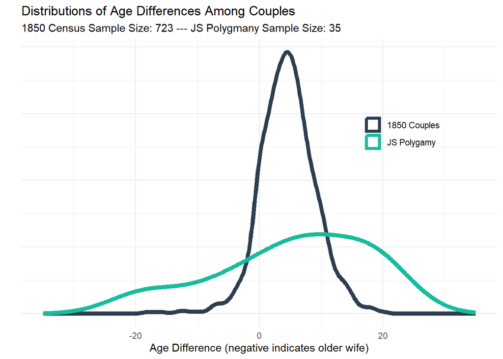

Summary Statistics: Age Differences Among Couples

| Group | Min | Median | Average | Max | SD | Sample Size |
| --- | --- | --- | --- | --- | --- | --- |
| 1850 Couples | -18 | 5 | 4.6 | 20 | 4.485 | 723 |
| JS Polygamy | -21 | 7 | 5.343 | 23 | 12.34 | 35 |

While there is skew observed, both groups are representative of the sample. The data concerning Smith’s Polygamy is all of the data of that population. The 1850 US Sample, being well over 30 and a random sample, likely represents the population well.

It appears from the visualization that Smith’s plural marriages tended to have a higher age gap then contemporary norms. An inferential statistical test will yield insight into the true significance of any observed differences.

#### Statistical Test and Conclusion

The most appropriate test for the data in hand is an independent sample t test. This test will yield two helpful data points: a test statistic indicating the difference in averages, and a p value telling how probable it would be to randomly encounter such a difference.

A confidence level of 97.5% will be used, and thus a significance of 0.025 will be needed to accept the alternative hypothesis. A p value below the significance ($p < 0.025$) will result in rejecting the null hypothesis.

Two Sample T-test: Age gaps not significantly different (continued below)

| Test statistic | df | P value | Alternative hypothesis |
| --- | --- | --- | --- |
| -0.355 | 34.44 | 0.7248 | two.sided |

| mean in group 1850 Couples | mean in group JS Polygamy |
| --- | --- |
| 4.6 | 5.343 |

In other words, there is no reason to believe that the age gaps withing Smith’s marriages were in any way significantly higher or lower than contemporary trends.

## Analysis Conclusion

In conclusion, across the six secondary questions asked, there is only one instance of Smith departing from societal norms or having questionable practices. This involved the fact that there is sufficient evidence to conclude that Smith’s plural wives were, on average, significantly older when married to Smith than would be expected.

Thus, I conclude that Smith did not use polygamy as a way to justify and engage in questionable or inappropriate actions.

While the practice of polygamy in the United States was unusual then and still is now, Smith seem to have stayed within the laws he set forth as a religious leader, within local customs, and within the trust of those closest to him.

[^1]: Steven Ruggles, Sarah Flood, Matthew Sobek, Daniel Backman, Annie Chen, Grace Cooper, Stephanie Richards, Renae Rodgers, and Megan Schouweiler. IPUMS USA: Version 15.0 [dataset]. Minneapolis, MN: IPUMS, 2024. https://doi.org/10.18128/D010.V15.0
[^2]: [APA on Defining Pedophilia](https://dictionary.apa.org/pedophilia)
[^3]: [DSM-V on Pedophilia](https://www.mredscircleoftrust.com/storage/app/media/DSM%205%20TR.pdf#page=1052)
[^4]: [llinois Historical Marriage Laws](https://www.chipublib.org/blogs/post/who-can-i-marry-a-chicago-history-2/)
[^5]: [llinois Historical Marriage Laws](https://www.chipublib.org/blogs/post/who-can-i-marry-a-chicago-history-2/)